# Machine Learning

```r
Elite <- rep("No", nrow(college))
Elite[college$Top10perc > 50] <- "Yes"
Elite_1 <- as.factor(Elite)
college <- data.frame(college, Elite_1)
str(college)
```

```
## 'data.frame':    777 obs. of  19 variables:
##  $ Private    : Factor w/ 2 levels "No","Yes": 2 2 2 2 2 2 2 2 2 2 ...
##  $ Apps       : int  1660 2186 1428 417 193 587 353 1899 1038 582 ...
##  $ Accept     : int  1232 1924 1097 349 146 479 340 1720 839 498 ...
##  $ Enroll     : int  721 512 336 137 55 158 103 489 227 172 ...
##  $ Top10perc  : int  23 16 22 60 16 38 17 37 30 21 ...
##  $ Top25perc  : int  52 29 50 89 44 62 45 68 63 44 ...
##  $ F.Undergrad: int  2885 2683 1036 510 249 678 416 1594 973 799 ...
##  $ P.Undergrad: int  537 1227 99 63 869 41 230 32 306 78 ...
##  $ Outstate   : int  7440 12280 11250 12960 7560 13500 13290 13868 15595 10468 ...
##  $ Room.Board : int  3300 6450 3750 5450 4120 3335 5720 4826 4400 3380 ...
##  $ Books      : int  450 750 400 450 800 500 500 450 300 660 ...
##  $ Personal   : int  2200 1500 1165 875 1500 675 1500 850 500 1800 ...
##  $ PhD        : int  70 29 53 92 76 67 90 89 79 40 ...
##  $ Terminal   : int  78 30 66 97 72 73 93 100 84 41 ...
##  $ S.F.Ratio  : num  18.1 12.2 12.9 7.7 11.9 9.4 11.5 13.7 11.3 11.5 ...
##  $ perc.alumni: int  12 16 30 37 2 11 26 37 23 15 ...
##  $ Expend     : int  7041 10527 8735 19016 10922 9727 8861 11487 11644 8991 ...
##  $ Grad.Rate  : int  60 56 54 59 15 55 63 73 80 52 ...
##  $ Elite_1    : Factor w/ 2 levels "No","Yes": 1 1 1 2 1 1 1 1 1 1 ...
```

Use the summary() function to see how many elite universities there are. Now use the plot() function to produce side-by-side boxplots of Outstate versus Elite.

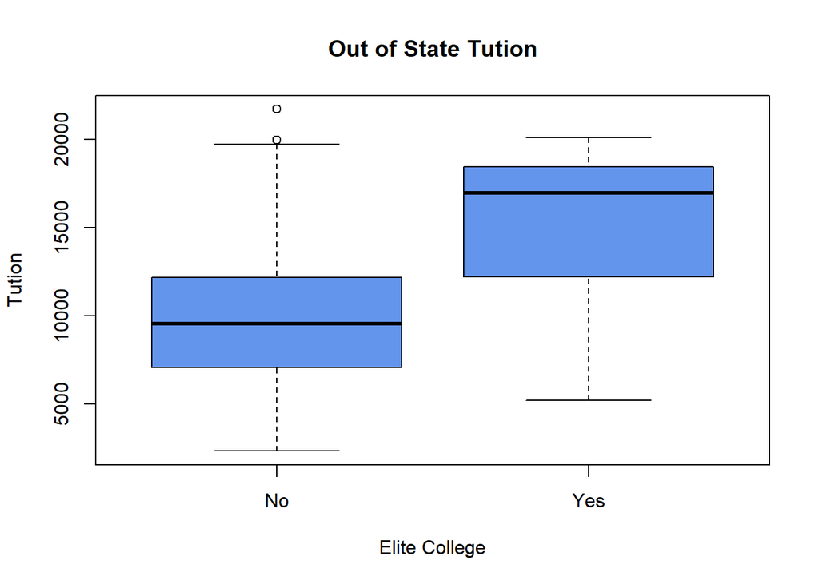

```r
plot(college$Elite,college$Outstate, main = "Out of State Tution", xlab = "Elite College", ylab = "Tution", col = "cornflowerblue")
```

22. Use the hist() function to produce some histograms with differing numbers of bins for a few of the quantitative variables. You may find the command par(mfrow = c(2, 2)) useful: it will divide the print window into four regions so that four plots can be made simultaneously. Modifying the arguments to this function will divide the screen in other ways.

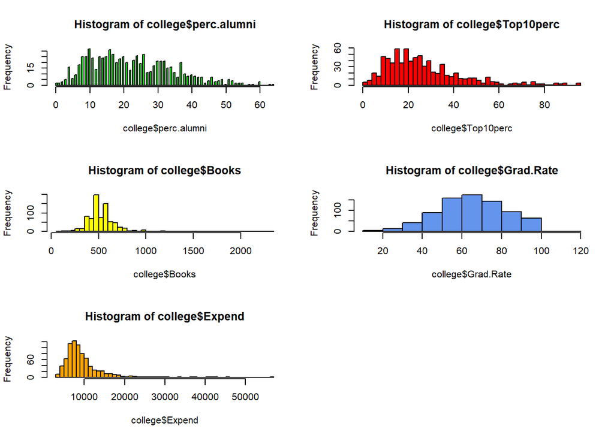

```r
par(mfrow = c(3,2))
hist(college$perc.alumni,breaks = 100, col = "green")
hist(college$Top10perc, breaks = 50, col = "red")
hist(college$Books, breaks = 40, col = "yellow")
hist(college$Grad.Rate, col = "cornflowerblue")
hist(college$Expend,breaks = 50, col = "orange")
```

6. Continue exploring the data, and provide a brief summary of what you discover.

```r
college_1 <- data.frame(exp = college$Expend,elite = Elite_1, num_phd = college$PhD,alumn_perc = college$perc.alumni, s_f_ratio = college$S.F.Ratio)
expend <- lm(exp~elite+num_phd+alumn_perc+s_f_ratio,data=college_1)
summary(expend)
```

```
##
## Call:
## lm(formula = exp ~ elite + num_phd + alumn_perc + s_f_ratio,
##     data = college_1)
##
## Residuals:
##    Min     1Q Median     3Q    Max
##  -8363  -1646   -401   1089  33098
##
## Coefficients:
##              Estimate Std. Error t value Pr(>|t|)
## (Intercept) 10373.268    826.686  12.548  < 2e-16 ***
## eliteYes     5663.073    457.306  12.384  < 2e-16 ***
## num_phd        78.211      8.131   9.619  < 2e-16 ***
## alumn_perc     37.387     11.251   3.323 0.000932 ***
## s_f_ratio    -554.641     34.668 -15.999  < 2e-16 ***
## ---
## Signif. codes:  0 '***' 0.001 '**' 0.01 '*' 0.05 '.' 0.1 ' ' 1
##
## Residual standard error: 3429 on 772 degrees of freedom
## Multiple R-squared:  0.5709, Adjusted R-squared:  0.5687
## F-statistic: 256.8 on 4 and 772 DF,  p-value: < 2.2e-16
```

```r
names(college_1)
```

```
## [1] "exp"        "elite"      "num_phd"    "alumn_perc" "s_f_ratio"
```

```r
library(moments)
library(knitr)


descriptive_statistics <- rbind(apply(college[,2:18],2,mean),
                                apply(college[,2:18],2,sd),
                                apply(college[,2:18],2,var),
                                apply(college[,2:18],2,skewness),
                                apply(college[,2:18],2,kurtosis))
descriptive_statistics <- round(descriptive_statistics,2)
rownames(descriptive_statistics) <- c("Mean", "Standard Deviation", "Variance", "Skewness", "Kurtosis")
descriptive_statistics
```

```
##                           Apps     Accept    Enroll Top10perc Top25perc
## Mean                   3001.64    2018.80    779.97     27.56     55.80
## Standard Deviation     3870.20    2451.11    929.18     17.64     19.80
## Variance           14978459.53 6007959.70 863368.39    311.18    392.23
## Skewness                  3.72       3.41      2.69      1.41      0.26
## Kurtosis                 29.59      21.81     11.77      5.19      2.43
##                    F.Undergrad P.Undergrad    Outstate Room.Board    Books
## Mean                   3699.91      855.30    10440.67    4357.53   549.38
## Standard Deviation     4850.42     1522.43     4023.02    1096.70   165.11
## Variance           23526579.33  2317798.85 16184661.63 1202743.03 27259.78
## Skewness                  2.61        5.68        0.51       0.48     3.48
## Kurtosis                 10.64       57.67        2.58       2.81    31.14
##                     Personal    PhD Terminal S.F.Ratio perc.alumni      Expend
## Mean                 1340.64  72.66    79.70     14.09       22.74     9660.17
## Standard Deviation    677.07  16.33    14.72      3.96       12.39     5221.77
## Variance           458425.75 266.61   216.75     15.67      153.56 27266865.64
## Skewness                1.74  -0.77    -0.81      0.67        0.61        3.45
## Kurtosis               10.07   3.55     3.23      5.54        2.90       21.64
##                    Grad.Rate
## Mean                   65.46
## Standard Deviation     17.18
## Variance              295.07
## Skewness               -0.11
## Kurtosis                2.79
```

After exploring the data, I wanted to discover the average treatment effect of expenditure per student and going to an elite school. What I found was surprising. Holding the variables PHD, S/F Ratio, Percent Alumni who donate fixed, I found that the average instructional expenditure per student increases by $5663 dollars. According to the descriptive statistics above, this is approximately one full standard deviation higher than students who do not attend elite schools. Reasons why are most likely related to endowment levels and tuition levels.